# Coursera- Practical Machine Learning

Yuting WANG

June 22, 2014

## 1. Data Explore

```r
train = read.csv('pml-training.csv', header = T)
test = read.csv('pml-testing.csv', header = T)
```

After loading the training and testing data, we can see there are many NAs in those dataframes.

I used a randomForest model to first check the importance of each feature.

Train data set is used. To simplify the problem, I only used complete cases.

```r
comp.df = na.omit(train)
```

Before applying the model, I removed some of the less related features, including time feature, features that contain ‘DIV’ and ‘user_name’ feature.

```r
name.time <- grep('time', names(comp.df))
#Remove features with time information
comp.df = comp.df[, -c(name.time)]
comp.df = comp.df[, 3:ncol(comp.df)]
rm = 0
for(i in 1:ncol(comp.df)){
        if(length(grep('DIV', comp.df[,i])) > 0)
                rm = c(rm, i)
}
rm = rm[-1]
#Remove features that contain 'DIV'
comp.df <- comp.df[,-rm]
```

**Use RandomForest to see the importance of features**

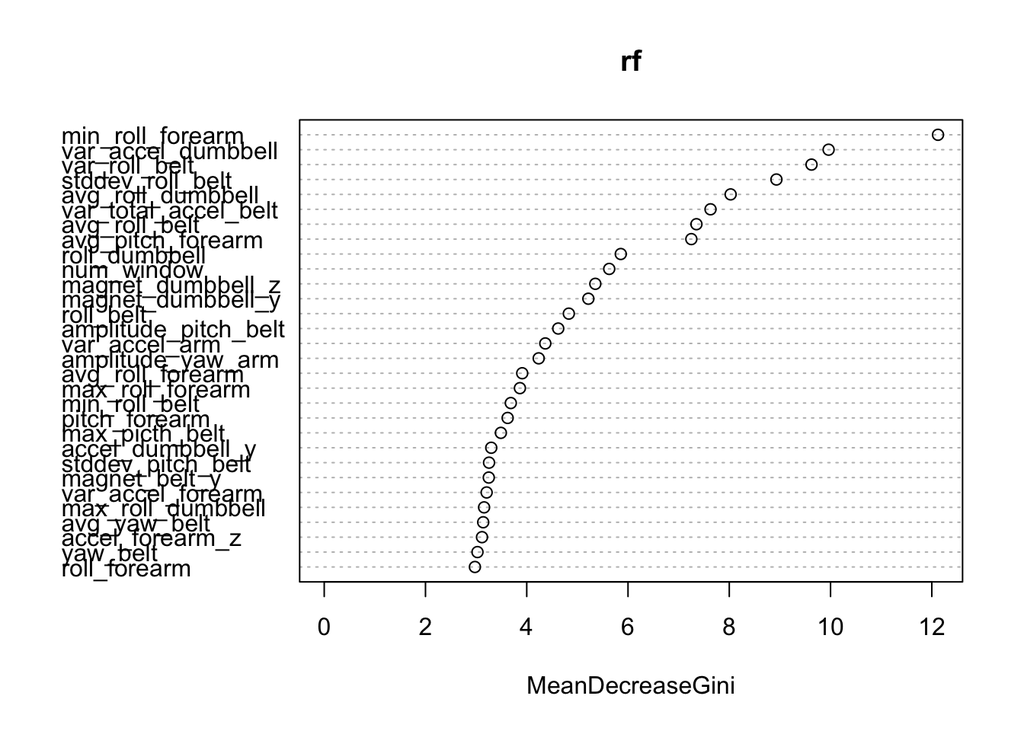

```r
library(randomForest)
rf <- randomForest(classe ~., data = comp.df)
varImpPlot(rf)
```

```r
most.imp <- rf$importance[order(rf$importance,decreasing = T),][1:25]
imp.var <- row.names(data.frame(most.imp))
```

We can see the most important features here. I saved the column names of the first most important features in imp.var variable for furute model building purpose.

**Testing set basic exam**

There are many columns that only contain NAs. First I removed them since there is no information in those columns.

```r
null.col = 0
for(i in 1:ncol(test)){
        if(length(which(is.na(test[,i]))) == nrow(test)){
                null.col <- c(null.col, i)
        }
}

null.col <- null.col[-1]
testset <- test[, -null.col]
```

Then remove time features and name features

```r
testset = testset[, -c(name.time)]
testset <- testset[, 3:ncol(testset)]
```

```r
ncol(testset)
```

```
## [1] 55
```

```r
nrow(testset)
```

```
## [1] 20
```

Now I checked now many features remains in test set are also in the most important features generated above:

```r
imp <- names(testset)[which(names(testset) %in% imp.var)]
imp
```

```
## [1] "num_window"        "roll_belt"         "magnet_belt_y"
## [4] "roll_dumbbell"     "accel_dumbbell_y"  "magnet_dumbbell_y"
## [7] "magnet_dumbbell_z" "pitch_forearm"
```

```r
#Extract the desired features
training <- train[imp]
training$classe <- train$classe
```

```r
rf_3 <- randomForest(classe ~ ., data = training)
rf_3
```

```
##
## Call:
##  randomForest(formula = classe ~ ., data = training)
##                Type of random forest: classification
##                      Number of trees: 500
## No. of variables tried at each split: 2
##
##         OOB estimate of  error rate: 0.23%
## Confusion matrix:
##      A    B    C    D    E class.error
## A 5577    0    1    2    0   0.0005376
## B    7 3787    1    2    0   0.0026337
## C    0    8 3412    2    0   0.0029223
## D    0    1    6 3209    0   0.0021766
## E    0    1    0   14 3592   0.0041586
```

We see here the out of bag error rate is very low.

Use cross validation:

```r
set.seed(0)
rf.cv <- rfcv(training[, 1:8], training[,9], cv.fold = 5)
rf.cv$error.cv
```

```
##         8         4         2         1
## 0.0030578 0.0022424 0.0105494 0.0002039
```

The result of cross validation is very promissing. Thus the model is valid.

**Applly model to testing sets**

First, removed the unused features in the test set

```r
testing <- test[imp]
```

Then apply the model

```r
pred <- predict(rf_3, testing)
```

Create the answers

```r
pml_write_files = function(x){
  n = length(x)
  for(i in 1:n){
    filename = paste0("problem_id_",i,".txt")
    write.table(x[i],file=filename,quote=FALSE,row.names=FALSE,col.names=FALSE)
  }
}
pml_write_files(pred)
```